# Getting started with the inapplicable package

Martin R. Smith

2017-11-04

`inapplicable` is an R package that allows parsimony search on morphological datasets that contain inapplicable data, following the algorithm proposed by Brazeau, Guillerme and Smith (2017).

In brief, this algorithm modifies the Fitch algorithm to count the total number of homoplasious events on a tree.

# Installation

The inapplicable package can be installed as any other package. To get the latest stable version from CRAN, type

```r
install.packages('inapplicable')
```

into the R command line. To get the latest development version from GitHub, it’s

```r
if (!require('devtools')) install.packages('devtools')
devtools::install_github('ms609/inapplicable')
```

You’ll probably need to install [Rtools](https://cran.r-project.org/bin/windows/Rtools/) to install the latest version, which may be complicated. If that’s well within your comfort zone, then you may wish to install a byte-compiled version of `ape` for additional speed:

```r
install.packages('ape', type='source', INSTALL_opts='--byte-compile')
```

Once installed, load the inapplicable package into R using

```r
library(inapplicable)
```

# Scoring a tree, and conducting a tree search

Here’s an example of using the package to conduct tree search. You can load your own dataset like so:

```r
my.data <- ape::read.nexus.data('path/to/file')
```

But for now, we’ll use the Vinther *et al.* dataset that’s bundled with the package. This dataset is small enough that it runs reasonably quickly, but its phylogenetic signal is obscure enough that it can require Ratchet searches to escape from local optima.

```r
data(inapplicable.datasets)
my.data <- inapplicable.datasets[['Vinther2008']]
my.phyDat <- phangorn::phyDat(my.data, type='USER', levels=c(0:9, '-'))
```

We can generate a random tree and calculate its parsimony score thus:

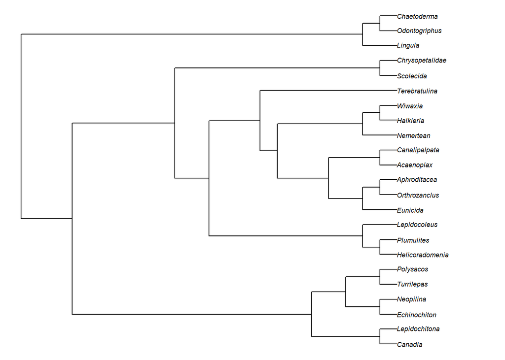

```r
set.seed(0) # Set random seed so that random functions will generate consistent output in this document
random.tree <- TreeSearch::RandomTree(my.phyDat)
par(mar=rep(0.25, 4), cex=0.75) # make plot easier to read
plot(random.tree)
```

```r
InapplicableFitch(random.tree, my.phyDat)
```

```
## [1] 189
```

It helps tree search if we start with a tree that’s a little closer to optimal; perhaps a neighbour-joining tree:

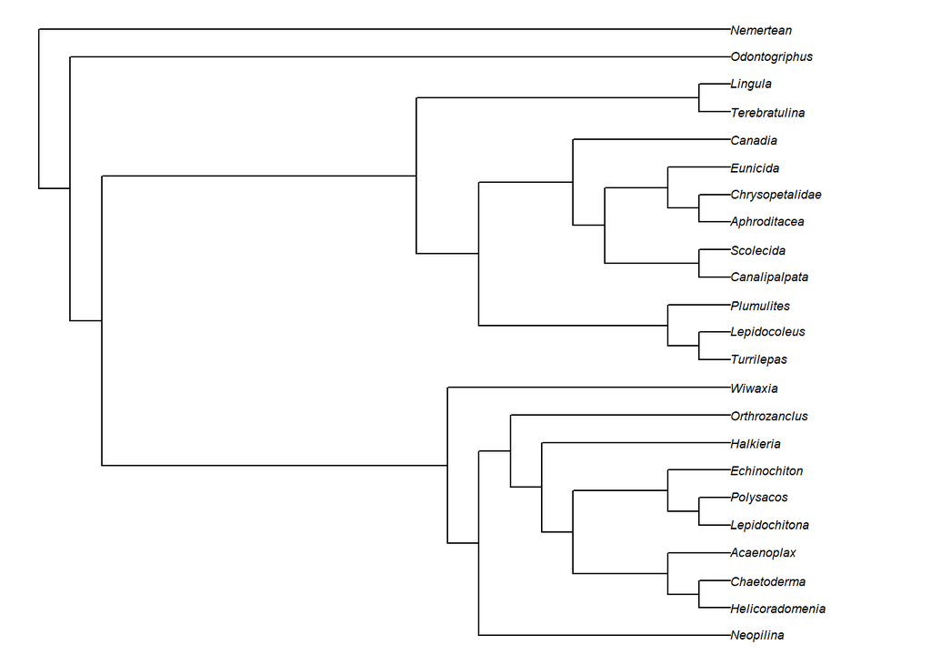

```r
nj.tree <- ape::nj(phangorn::dist.hamming(my.phyDat))
# We need to set an arbitrary ougroup so that all nodes bifurcate
nj.tree <- ape::root(nj.tree, outgroup=names(my.phyDat)[1], resolve.root=TRUE)
nj.tree$edge.length <- NULL
par(mar=rep(0.25, 4), cex=0.75) # make plot easier to read
plot(nj.tree)
```

```r
InapplicableFitch(nj.tree, my.phyDat)
```

```
## [1] 85
```

With the Vinther *et al.* 2008 dataset, brachiopods and nemerteans form an natural outgroup to the other taxa. If we wish, we can avoid making tree rearrangements that would mix ingroup and outgroup taxa. This will accellerate tree search, but it’s worth thinking carefully whether you can be perfectly confident that the ingroup and outgroup are mutually monophyletic. First we need to separate the ingroup from the outgroup:

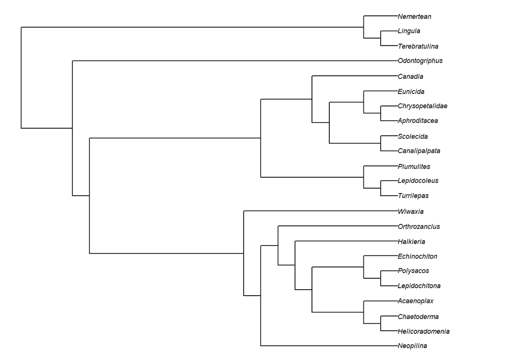

```r
outgroup <- c('Nemertean', 'Lingula', 'Terebratulina')
rooted.tree <- TreeSearch::EnforceOutgroup(nj.tree, outgroup)
par(mar=rep(0.25, 4), cex=0.75) # make plot easier to read
plot(rooted.tree)
```

Now let’s see whether a few Nearest-neighbour interchanges can find us a better tree score. This tends to be the quickest search to run, if not the most exhaustive. Using `RootedNNI` instead of `NNI` retains the position of the root, which you’ll usually want to do.

```r
better.tree <- BasicSearch(tree=rooted.tree, dataset=my.phyDat, Rearrange=TreeSearch::RootedNNI, verbosity=3)
```

```
##   - Initial score: 85
##     - Iteration 2 - Best score 85 hit 1 times
##     * Iteration 5 - New best score 84 found on 1 trees
##     - Iteration 7 - Best score 84 hit 2 times
##     - Iteration 11 - Best score 84 hit 3 times
##     - Iteration 12 - Best score 84 hit 4 times
##     * Iteration 15 - New best score 83 found on 1 trees
##     - Iteration 20 - Best score 83 hit 2 times
##     - Iteration 24 - Best score 83 hit 3 times
##     - Iteration 29 - Best score 83 hit 4 times
##     - Iteration 33 - Best score 83 hit 5 times
##     - Iteration 36 - Best score 83 hit 6 times
##     - Iteration 38 - Best score 83 hit 7 times
##     - Iteration 41 - Best score 83 hit 8 times
##     - Iteration 48 - Best score 83 hit 9 times
##     - Iteration 51 - Best score 83 hit 10 times
##     - Iteration 63 - Best score 83 hit 11 times
##     - Iteration 65 - Best score 83 hit 12 times
##     - Iteration 71 - Best score 83 hit 13 times
##     - Iteration 78 - Best score 83 hit 14 times
##     - Iteration 84 - Best score 83 hit 15 times
##     - Iteration 85 - Best score 83 hit 16 times
##     - Iteration 90 - Best score 83 hit 17 times
##     - Iteration 96 - Best score 83 hit 18 times
##   - Final score 83 found 18 times after 100 rearrangements
```

Using NNI helps to explore the region of treespace close to the local optimum, but SPR and TBR rearrangements are better at escaping local optima, and find better trees further away in tree space. Using more hits (`maxHits`) and more iterations (`maxIter`) also means we’ll move closer to an optimal tree.

```r
better.tree <- BasicSearch(better.tree, my.phyDat, maxHits=40, maxIter=100000, Rearrange=TreeSearch::RootedSPR, verbosity=2)
```

```
##   - Initial score: 83
##     * Iteration 177 - New best score 80 found on 1 trees
##     * Iteration 510 - New best score 79 found on 1 trees
##   - Final score 79 found 40 times after 2813 rearrangements
```

```r
better.tree <- BasicSearch(better.tree, my.phyDat, maxHits=40, maxIter=100000, Rearrange=TreeSearch::RootedTBR, verbosity=2)
```

```
##   - Initial score: 79
##   - Final score 79 found 40 times after 3193 rearrangements
```

That score’s looking better, but we might still be caught in a local optimum. A more comprehensive search of tree space can be accomplished using the parsimony ratchet (Nixon 1999). It might take a couple of minutes to run.

```r
best.tree <- RatchetSearch(better.tree, my.phyDat, verbosity=0, k=5)
attr(best.tree, 'score') # Each tree is labelled with its score during tree search
```

```
## [1] 79
```

No better trees were found. We can be pretty confident that there are no better trees than this one. Let’s take a look at it:

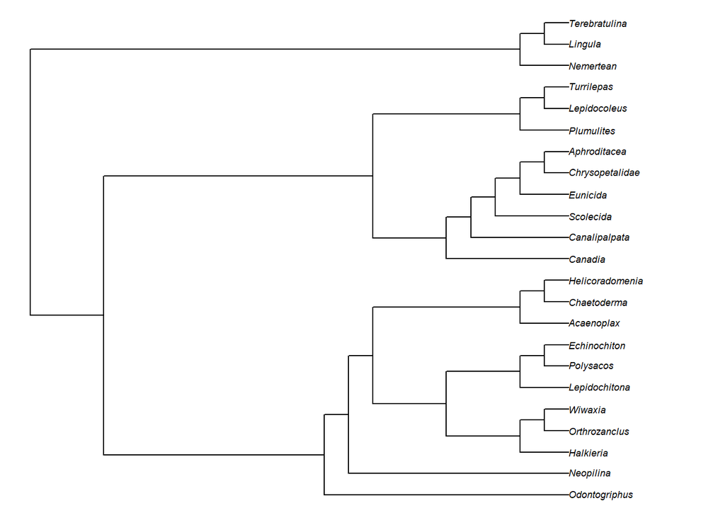

```r
par(mar=rep(0.25, 4), cex=0.75) # make plot easier to read
plot(best.tree)
```

This is, of course, just one most parsimonious tree; perhaps there are many.

One way to make a strict consensus of multiple optimal trees is to collect a number of trees from independent Ratchet iterations.

For each Ratchet iteration, we’ll conduct a TBR search to scan tree space, then an NNI search to hone in on the local optimum.

```r
my.consensus <- RatchetConsensus(best.tree, my.phyDat, rearrangements=list(TreeSearch::RootedTBR, TreeSearch::RootedNNI))
```

```
## Found 10 unique trees from  10 searches.
```

If ten independent runs all ended up at different trees, there are probably many more optimal trees out there to be found; perhaps we could repeat `RatchetConsensus` with `nSearch = 250` for a more exhaustive sampling of tree space. That would take a while though; for now, let’s check out our consensus tree:

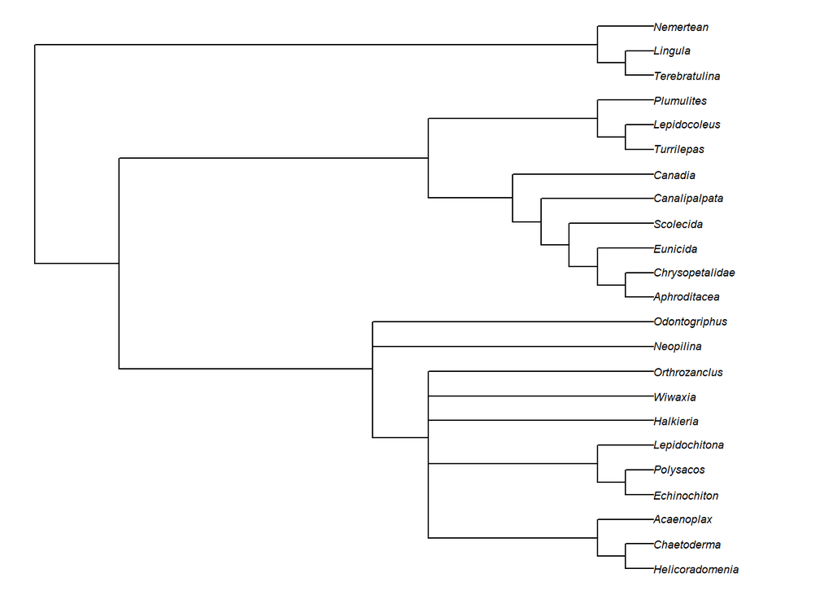

```r
par(mar=rep(0.25, 4), cex=0.75) # make plot easier to read
plot(ape::consensus(my.consensus))
```

# References

BRAZEAU, M. D., GUILLERME, T. and SMITH, M. R. 2017. [Morphological phylogenetic analysis with inapplicable data](https://www.biorxiv.org/content/early/2017/10/26/209775). *BioRxiv*. doi:10.1101/209775

NIXON, K. C. 1999. [The Parsimony Ratchet, a new method for rapid parsimony analysis](http://doi.wiley.com/10.1111/j.1096-0031.1999.tb00277.x). *Cladistics*, 15, 407–414. doi:10.1111/j.1096-0031.1999.tb00277.x